# k-Nearest Neighbors (k-NN)

## From Parametric to Non-Parametric

**Previous Methods (Days 9-12):**

- Linear Regression: Assumes linear relationship, estimates parameters via `LS`
- Logistic Regression: Assumes logistic relationship, estimates parameters via `MLE`
- Parametric means we estimate `parameters`

**Today’s Breakthrough:**

- **k-NN: No explicit model, no parameter optimization!**
- Makes predictions based purely on similarity to neighbors
- Our first **highly flexible** approach
- No `closed-form` solution, need a computational approach

## What Makes k-NN Different?

**Traditional Approach (Parametric):**

1. **Assume** a functional form (linear, logistic)
2. **Estimate** parameters through optimization (least squares, MLE)
3. **Predict** using learned parameters

**k-NN Approach (Non-Parametric):**

1. **Store** all training data
2. **Find** k nearest neighbors to new point
3. **Average** their responses (regression) or **vote** (classification)

**No optimization step! No parameters to estimate!**

## k-nearest neighbor classifier (example)

- predict class for new observation with highly non-linear boundary, \(k=5\)

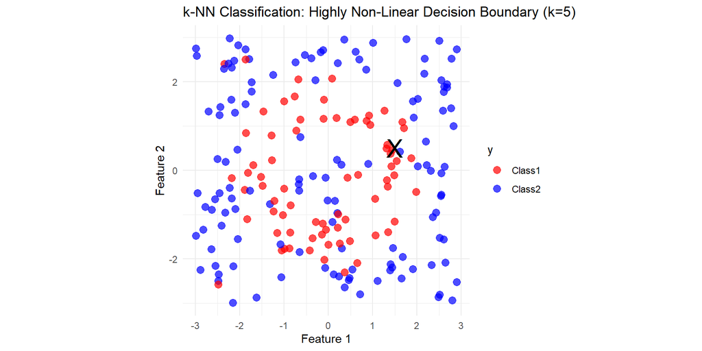

## k-nearest neighbor classifier

- Completely different way of approaching the problem
- Idea: We want to predict \(y^*\) with characteristics \(x^*_1, ..., x^*_p\) where \(*\) means testing data
1. Find the \(k\) cases in training data that are “closest” to the new case’s characteristics and use their responses (\(y\)) to predict \(y^*\)
2. Use responses of the “closest” cases to predict \(y^*\) using majority vote (most common response)
- Distance measure: how to find closest cases in a p-dimensional predictor space?
  - if \(x\)’s all quantitative: Euclidean distance
  - \(\sqrt{(x_{i1} - x_{j1})^2 + (x_{i2} - x_{j2})^2 + \cdots + (x_{ip} - x_{jp})^2}\)
  - When we only have 2 dimensions, it’s the same as calculating the hypotenuse

## Creating a Non-Linear Dataset: Our Testing Ground

- Summary of variables

```
       x1                 x2               y
 Min.   :-2.99857   Min.   :-2.9976   Class1:148
 1st Qu.:-1.56699   1st Qu.:-1.5571   Class2:252
 Median :-0.06526   Median :-0.1354
 Mean   :-0.01736   Mean   :-0.0716
 3rd Qu.: 1.48632   3rd Qu.: 1.3775
 Max.   : 2.97932   Max.   : 2.9760
```

- Class breakdown

```
# A tibble: 2 × 3
  y      count proportion
  <fct>  <int>      <dbl>
1 Class1   148       0.37
2 Class2   252       0.63
```

## k-nearest neighbor classifier

- *lazy-learner*
  - no formal model
  - no pre-processing of the training data (just need training data to predict test responses)
- Cons:
  - computationally intensive
  - accuracy depends on geometry of predictor space
  - how many neighbors \(k\) to pick?
    - what happens when \(k=1\)? \(k=n\)?
    - smaller \(k\): more overfitting (higher variance)
    - larger \(k\): less overfitting but more bias
- Why don’t we think of `k` as a parameter her?
  - a `parameter` is something estimated from the data
  - a `hyperparameter` is something that the data scientist sets

## Non-Linear k-nn example

- Let’s analyze our non-linear data with training data = 80% split, test data = 20%
  - what will the “X”’s be classified?

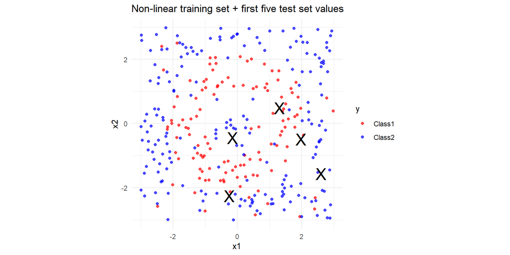

## Non-Linear k-nn example

- R package `class`:
  - `knn(train=, test=, cl=, k=)`
  - `train` and `test` are quantitative **predictor** data frames.
  - `cl` are the training set responses
- For the 80%/20% split on non-linear data:
  - using \(k=10\) gives accuracy of 79% and recall of 67%

## Visualizing Performance vs k

- Let’s plot `accuracy` vs `k`
- Accuracy increases then start falling

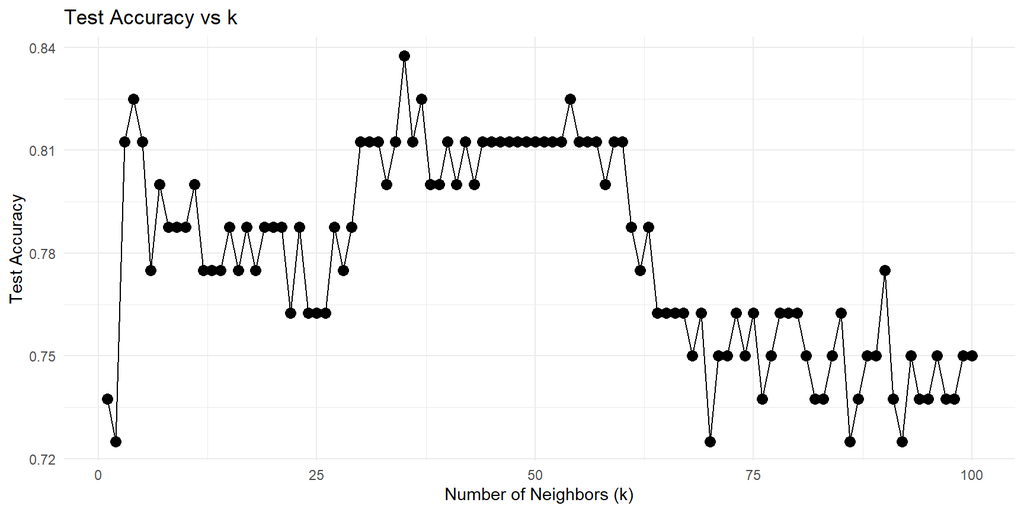

## k-nearest neighbor classifier

- accuracy depends on geometry of predictor space
  - depends *highly* upon the scale of your predictors!
  - predictors with larger variation will have larger influence on which cases are “nearest” neighbors

## Simple example:

- Which of the training cases is closest to the test case?

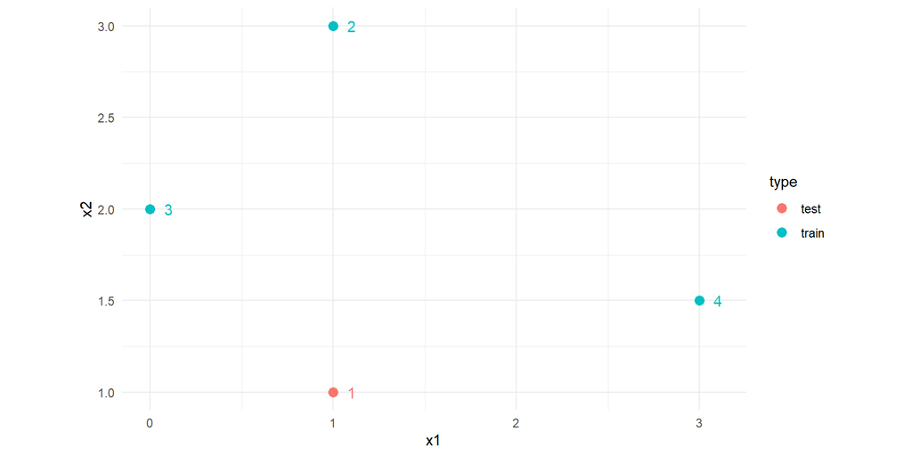

## Simple example:

- Can use the function `dist` to compute the Euclidean distance in \(R^p\) between cases in a data set with p predictors
- For \(R^2\), distance is \(\sqrt{(x-x_0)^2+(y-y_0)^2}\)

```
# A tibble: 4 × 4
     x1    x2 type  dist.from.1
  <dbl> <dbl> <chr>       <dbl>
1     1   1   test         0
2     1   3   train        2
3     0   2   train        1.41
4     3   1.5 train        2.06
```

- As the plot suggests, case 3 is closest to case 1

## Simple example II:

- Now consider this second set of data. How does it differ from first example?
- Which case is closest?

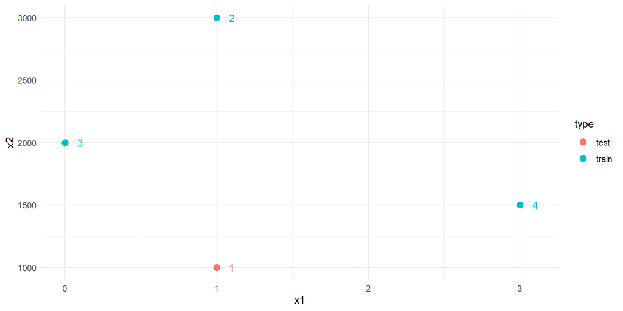

## Simple example II:

- Which training case is closest to 1?

```
# A tibble: 4 × 4
     x1    x2 type  dist.from.1
  <dbl> <dbl> <chr>       <dbl>
1     1  1000 test           0
2     1  3000 train       2000
3     0  2000 train       1000.
4     3  1500 train        500.
```

- Now case 4 is by far the closest!

## Simple example II:

- More obvious that 4 is closest if we use fixed axis ratio
- `x1` becomes meaningless and only `x2` distance matters

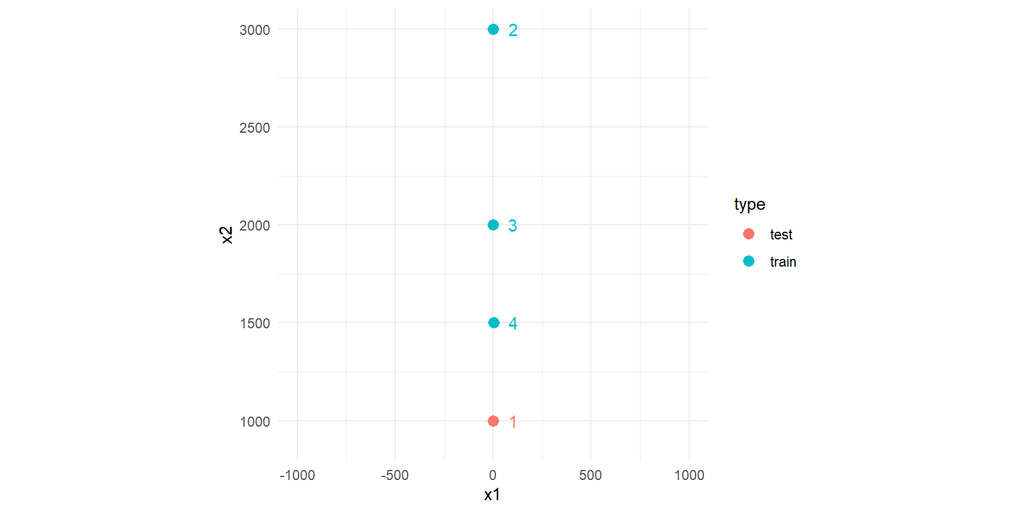

## Scaling is Critical!

- the Euclidean distance is a function of variable scale
  - Just plotting the data is misleading because axis scales may be different
- Methods relying on distance can be sensitive (i.e. not invariant) to the scale of the predictors
  - changing `x2` from kilometers (`x_df`) to meters (`x_df2`) changes the case that is closest to test case 1
  - The variables with larger scale will get more weight when computing distance
- With k-nn:
  - should `scale` (subtract `mean` divide by `sd`) predictors if they vary greatly in scale/variation
- Other classifiers (e.g trees, logistic regression) are invariant to linear transformations of predictors

## Dramatic Scaling Example: Multiplying by Constant

Let’s multiply the `x2` factor by 1,000.

```
       x1              x2_large
 Min.   :-2.99857   Min.   :-2997.6
 1st Qu.:-1.56699   1st Qu.:-1557.1
 Median :-0.06526   Median : -135.4
 Mean   :-0.01736   Mean   :  -71.6
 3rd Qu.: 1.48632   3rd Qu.: 1377.5
 Max.   : 2.97932   Max.   : 2976.0
```

## Performance Comparison: Unscaled vs Scaled

```
Original data accuracy: 0.787
x2*1000 UNSCALED accuracy: 0.613
x2*1000 SCALED accuracy: 0.775
```

**The Problem:** When x2 is 1000x larger than x1:

- x2 differences dominate the Euclidean distance calculation
- x1 becomes essentially irrelevant
- k-NN finds “nearest” neighbors based almost entirely on x2
- The circular pattern (which depends on BOTH x1 and x2) is lost!

## Comparing k-NN to Logistic Regression

```
               Method Accuracy Precision Recall Specificity F1_Score
1 Logistic Regression    0.512     0.258  0.333       0.589    0.291
2         k-NN (k=10)    0.787     0.640  0.667       0.839    0.653
```

- **k-NN dominates** across all metrics for this non-linear pattern
- **Precision difference**: k-NN has 0.382 higher precision
- **Recall difference**: k-NN has 0.334 higher recall
- **F1-Score**: k-NN’s balanced performance shows 0.362 improvement

**Why k-NN Excels Here:**

- **Circular/ring pattern**: Logistic regression’s linear boundary can’t capture the true decision boundary
- **Local adaptation**: k-NN adapts to local patterns rather than forcing global linearity
- **No parametric bias**: k-NN doesn’t assume a specific functional form

**When Logistic Regression Might Win:**

- Linear or near-linear decision boundaries
- Limited training data (k-NN needs sufficient neighbors)
- Need for interpretable coefficients
- High-dimensional sparse data

## Decision Boundaries: k-NN vs Logistic Regression

- k-NN performs well here because pattern is hightly non-linear

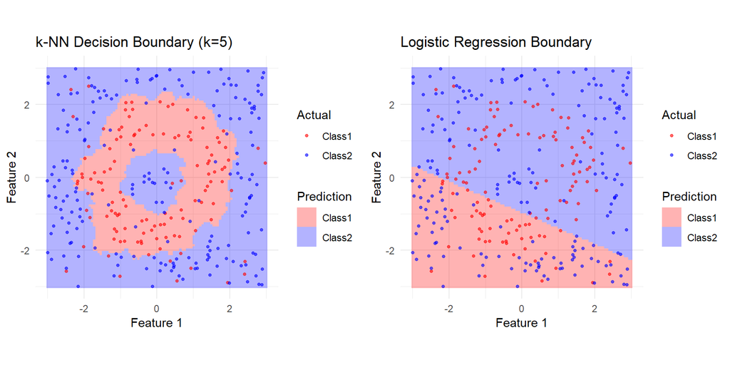

## Summary: k-NN as Our First Flexible Model

**Revolutionary Concept:**

- **No explicit optimization** - just similarity search
- **No parametric assumptions** - let data speak for itself
- **Highly flexible** - can capture complex patterns

**Key Takeaways:**

1. k-NN breaks from parametric tradition - no βs to estimate!
2. Flexibility controlled by k, not through parameter optimization
3. Scaling predictors is critical for good performance
4. Decision boundaries can be much more complex than linear